# Hyne - Logs - Green and Dry

#### Crook

```r
summary(m.best.crook_avg <- best.linear.model(L$crook_avg))
```

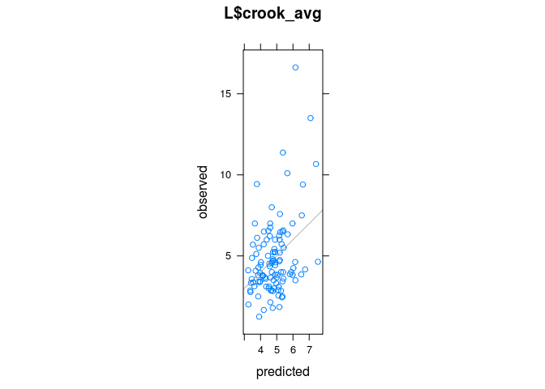

```
##
## Call:
## lm(formula = y ~ density + sweep.prod + m_waist, data = LL)
##
## Residuals:
##     Min      1Q  Median      3Q     Max
## -3.3170 -1.4776 -0.2643  1.0128 10.4716
##
## Coefficients:
##              Estimate Std. Error t value Pr(>|t|)
## (Intercept) 11.653904   2.953953   3.945 0.000144 ***
## density     -0.007949   0.003093  -2.570 0.011562 *
## sweep.prod   2.111823   0.877651   2.406 0.017849 *
## m_waist     -1.155524   0.645883  -1.789 0.076461 .
## ---
## Signif. codes:  0 '***' 0.001 '**' 0.01 '*' 0.05 '.' 0.1 ' ' 1
##
## Residual standard error: 2.198 on 106 degrees of freedom
## Multiple R-squared:  0.1473, Adjusted R-squared:  0.1232
## F-statistic: 6.105 on 3 and 106 DF,  p-value: 0.0007164
```

```r
summary(m.best.crook_50 <- best.linear.model(L$crook_50))
```

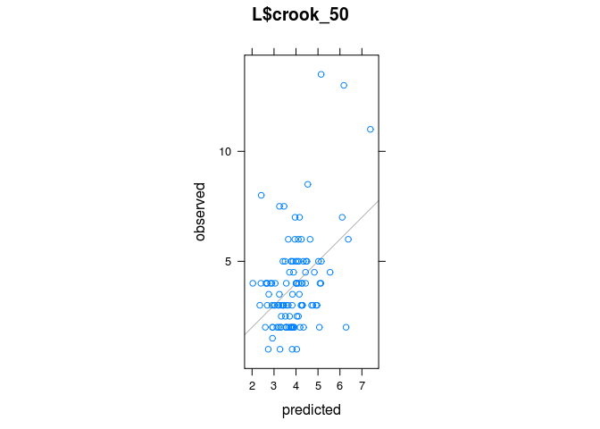

```
##
## Call:
## lm(formula = y ~ SWV + density + sweep.prod + m_taper, data = LL)
##
## Residuals:
##     Min      1Q  Median      3Q     Max
## -4.2772 -1.3010 -0.3075  0.9454  8.3582
##
## Coefficients:
##               Estimate Std. Error t value Pr(>|t|)
## (Intercept) 17.8230517  4.7148280   3.780 0.000261 ***
## SWV         -0.0015231  0.0008867  -1.718 0.088776 .
## density     -0.0090893  0.0029451  -3.086 0.002592 **
## sweep.prod   1.9155031  0.8246375   2.323 0.022116 *
## m_taper     -0.1087701  0.0709175  -1.534 0.128098
## ---
## Signif. codes:  0 '***' 0.001 '**' 0.01 '*' 0.05 '.' 0.1 ' ' 1
##
## Residual standard error: 1.999 on 105 degrees of freedom
## Multiple R-squared:  0.1763, Adjusted R-squared:  0.1449
## F-statistic: 5.617 on 4 and 105 DF,  p-value: 0.0003891
```

```r
summary(m.best.crook_75 <- best.linear.model(L$crook_75))
```

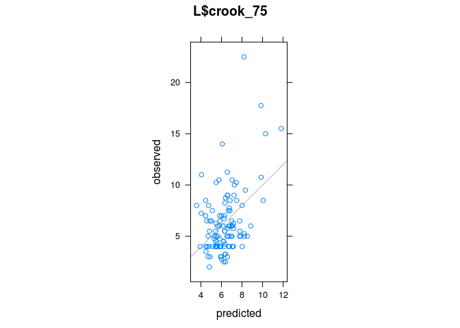

```
##
## Call:
## lm(formula = y ~ SWV + density + sweep.prod + m_taper, data = LL)
##
## Residuals:
##     Min      1Q  Median      3Q     Max
## -4.0136 -1.8490 -0.7262  1.1790 14.3093
##
## Coefficients:
##              Estimate Std. Error t value Pr(>|t|)
## (Intercept) 28.164952   6.939429   4.059 9.52e-05 ***
## SWV         -0.002288   0.001305  -1.753 0.082520 .
## density     -0.014720   0.004335  -3.396 0.000967 ***
## sweep.prod   2.879757   1.213727   2.373 0.019481 *
## m_taper     -0.150029   0.104379  -1.437 0.153590
## ---
## Signif. codes:  0 '***' 0.001 '**' 0.01 '*' 0.05 '.' 0.1 ' ' 1
##
## Residual standard error: 2.942 on 105 degrees of freedom
## Multiple R-squared:  0.1925, Adjusted R-squared:  0.1618
## F-statistic: 6.258 on 4 and 105 DF,  p-value: 0.0001479
```

#### Combination Warp

Stan combined bow and crook using WPA grade limits.

```r
combined_warp = L$crook_avg/75 + L$bow_avg/25
summary(m.best.combined_warp <- best.linear.model(combined_warp))
```

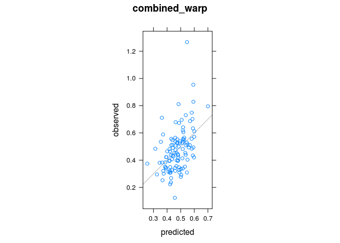

```
##
## Call:
## lm(formula = y ~ SWV + density + m_taper + m_whorliness, data = LL)
##
## Residuals:
##      Min       1Q   Median       3Q      Max
## -0.33366 -0.09632 -0.01685  0.06353  0.72041
##
## Coefficients:
##                Estimate Std. Error t value Pr(>|t|)
## (Intercept)   2.242e+00  3.370e-01   6.654 1.33e-09 ***
## SWV          -2.745e-04  6.364e-05  -4.313 3.65e-05 ***
## density      -7.438e-04  2.126e-04  -3.498 0.000689 ***
## m_taper      -9.980e-03  5.540e-03  -1.802 0.074491 .
## m_whorliness -8.014e-02  5.319e-02  -1.507 0.134860
## ---
## Signif. codes:  0 '***' 0.001 '**' 0.01 '*' 0.05 '.' 0.1 ' ' 1
##
## Residual standard error: 0.1459 on 105 degrees of freedom
## Multiple R-squared:  0.2133, Adjusted R-squared:  0.1833
## F-statistic: 7.116 on 4 and 105 DF,  p-value: 4.14e-05
```

What happens if we toss a couple of outliers?

```r
L$SWILogNumber[combined_warp>1.2] # 222
```

```
## [1] 222
```

```r
L$SWILogNumber[combined_warp<0.2] # 103
```

```
## [1] 103
```

```r
predictors = c('SWV',
            'm_volume','m_led','m_sed',
            'm_a0','m_a1','m_a2','m_taper','m_waist',
            'm_ovality','m_whorliness',
            'm_sweep1','m_sweep2',
            'weight','density',
            'hw.vfrac','sweep.prod')
subset = !L$SWILogNumber%in%c(103,222)
summary(m.best.combined_warp <- best.linear.model(combined_warp[subset], LL=L[subset,predictors]))
```

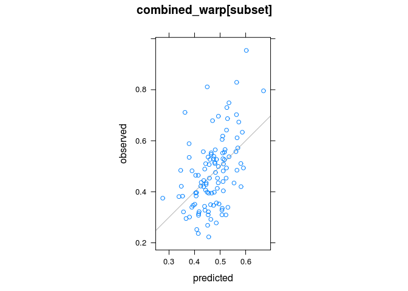

```
##
## Call:
## lm(formula = y ~ SWV + m_taper + density, data = LL)
##
## Residuals:
##      Min       1Q   Median       3Q      Max
## -0.23232 -0.07982 -0.00473  0.06620  0.36157
##
## Coefficients:
##               Estimate Std. Error t value Pr(>|t|)
## (Intercept)  1.943e+00  2.825e-01   6.877 4.69e-10 ***
## SWV         -2.425e-04  5.468e-05  -4.435 2.29e-05 ***
## m_taper     -1.532e-02  4.407e-03  -3.476 0.000743 ***
## density     -5.608e-04  1.800e-04  -3.115 0.002377 **
## ---
## Signif. codes:  0 '***' 0.001 '**' 0.01 '*' 0.05 '.' 0.1 ' ' 1
##
## Residual standard error: 0.1245 on 104 degrees of freedom
## Multiple R-squared:  0.2276, Adjusted R-squared:  0.2053
## F-statistic: 10.22 on 3 and 104 DF,  p-value: 5.923e-06
```

A little better, but nothing spectacular.

Can a random forest model do better?

```r
library(randomForest)
```

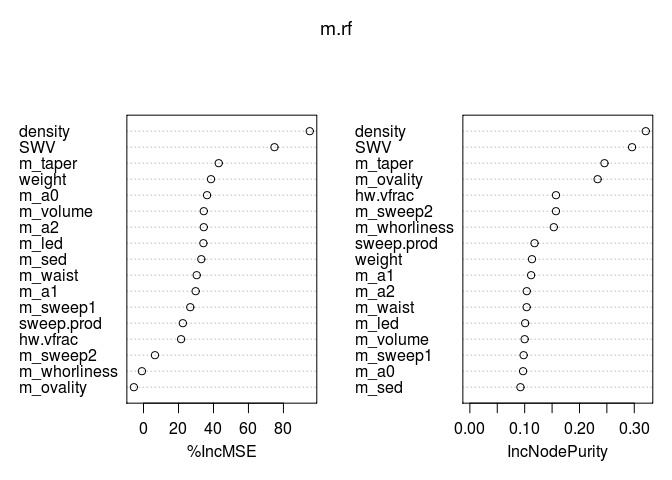

```r
LL=L[,predictors]
LL$combined_warp = combined_warp
LL = na.omit(LL)
m.rf <- randomForest(combined_warp ~ ., LL, importance=TRUE, ntree=50000)
par(mfcol=c(1,1))
varImpPlot(m.rf)
```

```r
print(m.rf)
```

```
##
## Call:
##  randomForest(formula = combined_warp ~ ., data = LL, importance = TRUE,      ntree = 50000)
##                Type of random forest: regression
##                      Number of trees: 50000
## No. of variables tried at each split: 5
##
##           Mean of squared residuals: 0.02536195
##                     % Var explained: 1.78
```

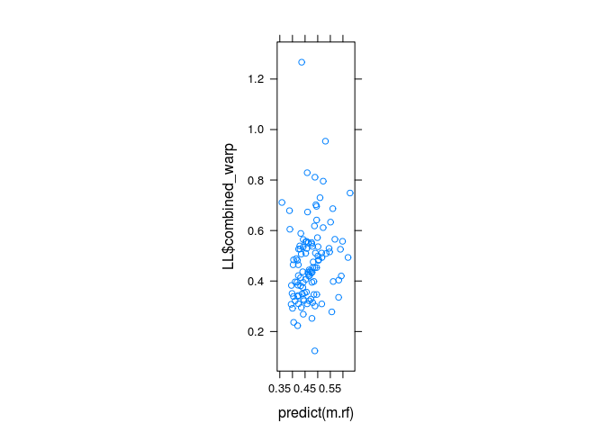

```r
xyplot(LL$combined_warp ~ predict(m.rf), aspect='iso')
```

Lousy results, but interesting that log green density turns up as the most favoured predictor, followed by SWV, taper and ovality.

## Conclusions

Best off using a dynamic estimate of board stiffness based on manual hitman velocity and CHH total density, but other measures of board stiffness (including Metriguard CLT) give similar results.

Green log SWV alone very poorly predicts average dry board stiffness.

## Todo

- bootstrap approaches to finding ‘best’ model